# North Auto Prices Research

Alejandro Alvarez

2026-05-30

# Abstract

This study examines factors affecting used vehicle prices in Northern California using a dataset of 61 Craigslist vehicle listings. Exploratory data analysis and multiple regression modeling were used to evaluate the relationship between vehicle price, mileage, year, brand, and vehicle type. The results indicate that mileage has a significant negative effect on vehicle price, while newer vehicles tend to retain higher resale values. The final regression model explains approximately 74% of the variation in vehicle prices, suggesting that these factors are important predictors of used vehicle value. This project demonstrates the use of R for data cleaning, visualization, statistical modeling, and predictive analysis.

# Introduction

This project analyzes used vehicle pricing patterns across Honda, Toyota, and Volkswagen vehicles in the Northern California market.

# Data Collection

The dataset was manually collected from Craigslist listings and cleaned to remove outliers, mechanic specials, collector vehicles, and incomplete listings.

# Exploratory Data Analysis

## Dataset Overview

This dataset includes 61 used vehicle listings collected from Craigslist in Northern California. The dataset includes vehicle price, mileage, model year, brand, vehicle type, fuel type, condition, and listing details.

## Mileage vs Price by Brand

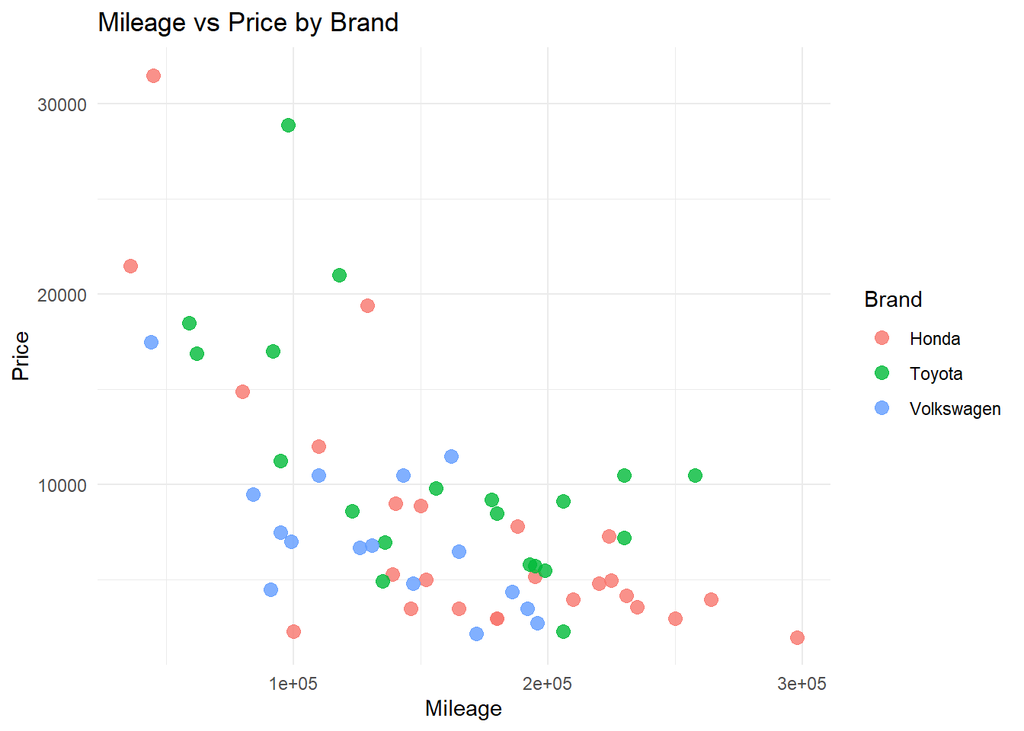

The scatterplot shows a clear negative relationship between mileage and vehicle price, indicating that vehicles generally lose value as mileage increases. Toyota vehicles tend to maintain higher prices at higher mileage levels compared to Honda and Volkswagen, suggesting stronger resale value and market confidence. Volkswagen vehicles appear more concentrated in the lower price ranges, which may indicate faster depreciation. Truck models also appear among the highest-priced observations, even with relatively high mileage, showing the strength of the truck resale market.

## Graph Price vs Mileage

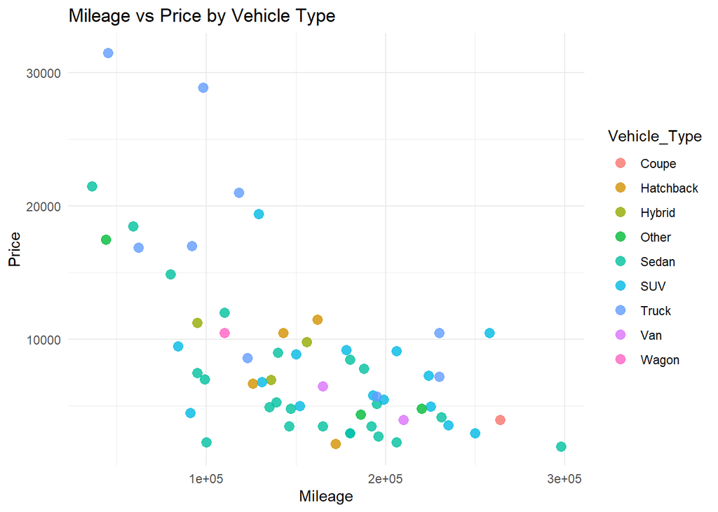

The graph shows that vehicle prices generally decline as mileage increases across all vehicle types. Trucks consistently appear among the highest-priced vehicles, even at high mileage levels, suggesting strong demand and slower depreciation. SUVs also maintain relatively strong resale value compared to sedans. Hybrid vehicles appear concentrated in moderate mileage and price ranges, reflecting continued consumer demand for fuel-efficient vehicles. Sedans and hatchbacks are more concentrated in the lower-price ranges, indicating faster depreciation and greater market supply.

## Vehicle Count by Brand

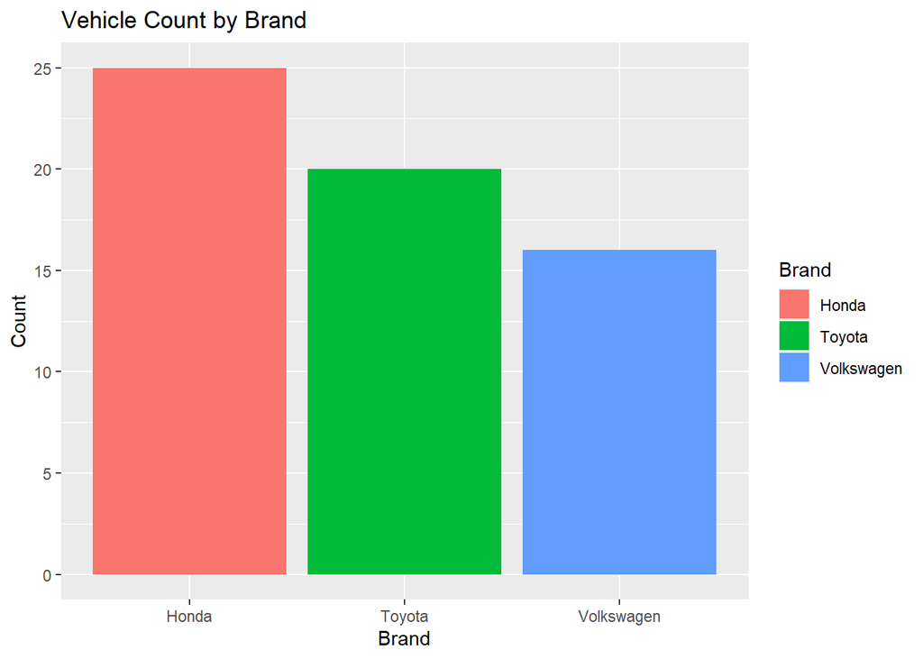

Summary

## Price Distribution Histogram

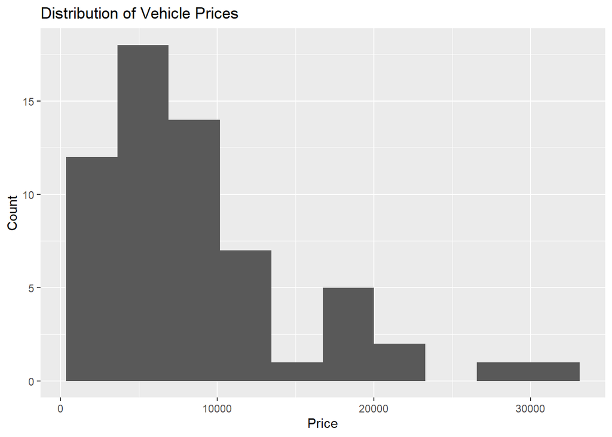

Summary The histogram shows how vehicle prices are distributed across the dataset. Most vehicles are concentrated in the lower-to-middle price range, while a smaller number of higher-priced vehicles create a right-skewed distribution. These higher-priced vehicles are likely newer models, trucks, or SUVs.

## Regression Analysis

To better understand the factors that influence used vehicle prices, a multiple linear regression model was estimated using vehicle mileage and model year as predictor variables. The goal is to determine how these characteristics affect resale value and evaluate the model’s ability to explain price variation across the sample.

## Model Specification

Price = β₀ + β₁(Mileage) + β₂(Year)

```
##
## Call:
## lm(formula = Price ~ Mileage + Year, data = cars)
##
## Residuals:
##    Min     1Q Median     3Q    Max
##  -6907  -3256  -1074   2274  15231
##
## Coefficients:
##               Estimate Std. Error t value Pr(>|t|)
## (Intercept) -5.685e+05  2.132e+05  -2.667 0.009907 **
## Mileage     -4.780e-02  1.223e-02  -3.909 0.000245 ***
## Year         2.911e+02  1.056e+02   2.756 0.007799 **
## ---
## Signif. codes:  0 '***' 0.001 '**' 0.01 '*' 0.05 '.' 0.1 ' ' 1
##
## Residual standard error: 4723 on 58 degrees of freedom
## Multiple R-squared:  0.4617, Adjusted R-squared:  0.4431
## F-statistic: 24.87 on 2 and 58 DF,  p-value: 1.584e-08
```

Results Interpretation

The regression results indicate that mileage has a statistically significant negative effect on vehicle price, meaning vehicles with higher mileage generally sell for lower prices. Vehicle year has a statistically significant positive effect, suggesting newer vehicles command higher resale values.

The model achieved an R-squared value of approximately 0.46, indicating that mileage and vehicle year explain about 46% of the variation in vehicle prices. While the model provides useful insights, additional variables such as vehicle condition, fuel type, brand, and location could improve predictive accuracy.

## Price Prediction Example

Using the regression model, a price prediction was generated for a vehicle with 120,000 miles and model year 2016.

```
##        1
## 12617.25
```

Predicted Price

The model predicts a vehicle price of approximately $12,617.

## Interpretation

This prediction demonstrates how regression analysis can be used to estimate vehicle values based on observable characteristics. Such models can help buyers evaluate listings and assist sellers in establishing competitive prices.

## Regression Analysis

A multiple linear regression model was estimated to examine how mileage, vehicle year, brand, and vehicle type influence used vehicle prices. By including multiple explanatory variables, the model provides a more comprehensive understanding of the factors affecting resale value.

## Model Specification

Price = f(Mileage, Year, Brand, Vehicle Type)

## Purpose

The objective of this model is to identify which vehicle characteristics significantly affect price and to evaluate how well these variables explain variation in the used vehicle market.

```
##
## Call:
## lm(formula = Price ~ Mileage + Year + Brand + Vehicle_Type, data = cars)
##
## Residuals:
##      Min       1Q   Median       3Q      Max
## -10580.3  -1559.2   -360.7   1632.8   7738.3
##
## Coefficients:
##                         Estimate Std. Error t value Pr(>|t|)
## (Intercept)           -8.065e+05  1.831e+05  -4.405 5.90e-05 ***
## Mileage               -4.623e-02  1.050e-02  -4.402 5.97e-05 ***
## Year                   4.128e+02  9.111e+01   4.531 3.91e-05 ***
## BrandToyota            6.574e+02  1.367e+03   0.481   0.6326
## BrandVolkswagen       -3.923e+03  1.422e+03  -2.758   0.0082 **
## Vehicle_TypeHatchback -5.637e+03  4.478e+03  -1.259   0.2142
## Vehicle_TypeHybrid    -8.984e+03  4.711e+03  -1.907   0.0625 .
## Vehicle_TypeOther     -6.424e+03  4.541e+03  -1.415   0.1636
## Vehicle_TypeSedan     -7.636e+03  3.928e+03  -1.944   0.0577 .
## Vehicle_TypeSUV       -6.557e+03  3.974e+03  -1.650   0.1055
## Vehicle_TypeTruck     -6.644e+02  4.285e+03  -0.155   0.8774
## Vehicle_TypeVan       -2.802e+03  4.520e+03  -0.620   0.5382
## Vehicle_TypeWagon     -4.540e+03  5.472e+03  -0.830   0.4108
## ---
## Signif. codes:  0 '***' 0.001 '**' 0.01 '*' 0.05 '.' 0.1 ' ' 1
##
## Residual standard error: 3624 on 48 degrees of freedom
## Multiple R-squared:  0.7378, Adjusted R-squared:  0.6722
## F-statistic: 11.25 on 12 and 48 DF,  p-value: 3.122e-10
```

Results Interpretation

The regression model explains approximately 74% of the variation in vehicle prices (R² = 0.738), indicating strong explanatory power.

Mileage has a statistically significant negative effect on price, meaning vehicles with higher mileage generally sell for lower prices. Vehicle year has a statistically significant positive effect, suggesting newer vehicles command higher resale values.

Among the brand variables, Volkswagen vehicles show a statistically significant negative relationship with price relative to the reference category, while Toyota vehicles do not differ significantly from the baseline brand. Most vehicle type categories were not statistically significant, indicating that mileage and vehicle age are the strongest predictors within this dataset.

Overall, the model demonstrates that depreciation and vehicle age are the primary drivers of used vehicle prices in this sample.

## Prediction Example

Using the regression model, a 2016 Toyota Sedan with 120,000 miles is predicted to have a market value of approximately $13,173.

This example demonstrates how regression analysis can be used to estimate vehicle prices based on observable characteristics and support data-driven pricing decisions.

```
##        1
## 13172.93
```

## Regression Plot

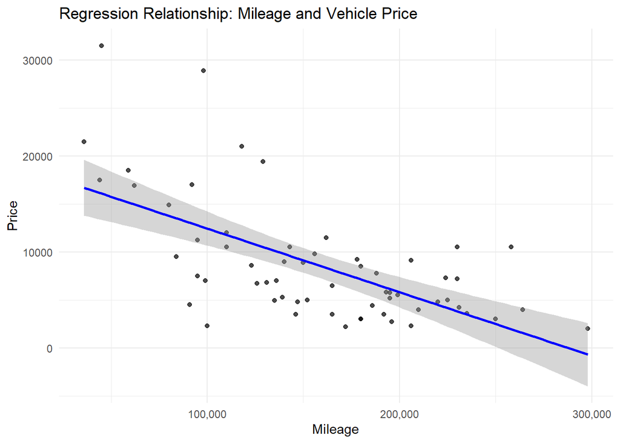

Regression Analysis

The regression plot illustrates the negative relationship between mileage and vehicle price. As mileage increases, vehicle prices generally decrease, reflecting the effects of depreciation. The downward-sloping regression line confirms the statistical findings from the regression model and highlights mileage as an important predictor of resale value.

## Conclusion

This project analyzed used vehicle pricing patterns across Honda, Toyota, and Volkswagen vehicles in the Northern California market using R. Exploratory data analysis showed that vehicle prices generally decrease as mileage increases, while newer vehicles tend to retain higher resale values. Visualizations revealed differences in pricing patterns across brands and vehicle types, with trucks and SUVs often maintaining stronger values than other vehicle categories.

The multiple regression model explained approximately 74% of the variation in vehicle prices (R² = 0.738). Mileage was found to have a significant negative effect on price, while vehicle year had a significant positive effect. These findings indicate that depreciation and vehicle age are among the strongest drivers of used vehicle values in this dataset.

Future improvements could include expanding the dataset to include more vehicle brands and observations, incorporating variables such as vehicle condition, fuel type, title status, and location, and developing more advanced machine learning models for vehicle price prediction.